# Тестовое задание

Вам представлена штатная численность предприятия, которое имеет офисы по всей России. Период наблюдения - 5 месяцев.  
Сотрудник, отвечающий за подготовку отчетности на предприятии, при анализе таблицы столкнулся с некоторыми проблемами, которые мешают подготовить отчет руководству.  
Помогите ему, изучите данные и решите поставленные задачи.  
Представленные данные:

**Таблица `Сотрудники`:**

1) `Период` - формат Дата (пропуски не допускаются);  
2) `ID должности` - целое число (пропуски не допускаются, уникальный на каждый период);  
3) `Табельный номер` - целое число (допускаются пропуски);  
4) `Город`- Текст (допускаются пропуски);  
5) `Должность` - Текст (допускаются пропуски);  
6) `ФИО` - Текст (допускаются пропуски).

**Таблица `Города`:** 1) `Федеральный округ` - Текст (пропуски не допускаются);  
2) `Регион` - Текст (пропуски не допускаются);  
3) `Город` - Текст (уникальный).

Задачи:  
**1. Предобработка таблицы:**  
1.1. В таблице есть ошибки данных (некорректный для поля тип данных, дубликат и пр.), укажите, как их обнаружили, и что предприняли для их устранения;  
1.2. Часть данных по некоторым должностям была утеряна, но известно, что ID имеет уникальную должность и локацию, и не меняется из периода в период, восстановите недостающие данные;  
1.3. Вытянуть строки с новыми штатными единицами, на которые еще не распределены должности и сотрудники. В графах Табельного номера и Должности проставить признак «Резерв»;  
**2. Построить сводную таблицу с разбивкой по месяцам со следующими показателями:**  
2.1. Количество действующих сотрудников (должностей);  
2.2. Количество свободных должностей (подсказка: табельный номер пустой);  
2.3. Доля свободных должностей от итого должностей;  
**3. Работа по дополнению предобработанной таблицы, добавьте следующие показатели:**  
3.1. Федеральные округа и Регионы;  
3.2. Количество месяцев поиска сотрудника по должности накопительно по каждому месяцу (н-р должность "директор" не заполнена в январе до марта включительно, а в апреле заполнена, результат получится следующим: январь - 1, февраль - 2, март - 3). Задание повышенной сложности, если не получится реализовать, то напишите ваши идеи, как бы это могло быть реализовано.  
**4. Ответьте на следующие вопросы, построив сводные таблицы исходя из дополненных данных пункта 3;**  
4.1. В каких городах наблюдается нехватка кадров на последний месяц? Отсортируйте по убыванию;  
4.2. В каком регионе работает наибольшее количество сотрудников на последний месяц? Отсортируйте по убыванию;  
4.3. Какие должности подвержены наибольшей текучести (подсказка: расчет из п.2.3)? Выведите наименование должности и коэффициенты текучести по месяцам, отразите первыми те должности, по которым наблюдалась наибольшая текучесть.  
**5. Визуализация (тип диаграммы и библиотека на ваше усмотрение);**  
5.1. Количество действующих сотрудников по Федеральным округам;  
5.2. Количество свободных должностей по регионам.

## Предобработка таблицы:

1.1. В таблице есть ошибки данных (некорректный для поля тип данных, дубликат и пр.), укажите, как их обнаружили, и что предприняли для их устранения;  
1.2. Часть данных по некоторым должностям была утеряна, но известно, что ID имеет уникальную должность и локацию, и не меняется из периода в период, восстановите недостающие данные;  
1.3. Вытянуть строки с новыми штатными единицами, на которые еще не распределены должности и сотрудники. В графах Табельного номера и Должности проставить признак «Резерв».

```python
# Импорт библиотек
import pandas as pd
import numpy as np
import matplotlib.pyplot as plt
import seaborn as sns
```

### Загрузка и исследование данных.

#### Таблица `Сотрудники`.

```python
# Функция отображения всех строк таблиц
pd.set_option('display.max_rows', None)
```

```python
# Считываем данные из xlsx-файлов в датафрейм и сохраняем в переменные
employees = pd.read_excel('Сотрудники.xlsx')
cities = pd.read_excel('Города.xlsx')
```

```python
# Вывод случайных строк таблицы
employees.sample(5)
```

|  | Период | ID должности | Табельный номер | Город | Должность | ФИО |
| --- | --- | --- | --- | --- | --- | --- |
| 2596 | 44986 | 1598 | 2799.0 | Прокопьевск | главный персональный менеджер | Бобров А. |
| 2602 | 44986 | 1604 | 2805.0 | Зубова Поляна | главный менеджер | Селезнев С. |
| 3959 | 45017 | 1962 | 3163.0 | Вольск | директор | Петров Ж. |
| 205 | 44927 | 1205 | 2406.0 | Чистополь | директор | Бобров Р. |
| 4113 | 45047 | 1117 | 2318.0 | Пыть-Ях | руководитель группы | Петров Ю. |

```python
# Вывод информации о таблице
employees.info()
```

```
<class 'pandas.core.frame.DataFrame'>
RangeIndex: 5001 entries, 0 to 5000
Data columns (total 6 columns):
 #   Column           Non-Null Count  Dtype
---  ------           --------------  -----
 0   Период           5001 non-null   int64
 1   ID должности     5001 non-null   object
 2   Табельный номер  4883 non-null   float64
 3   Город            4880 non-null   object
 4   Должность        4856 non-null   object
 5   ФИО              4883 non-null   object
dtypes: float64(1), int64(1), object(4)
memory usage: 234.5+ KB
```

```python
# Приведение столбца к формату даты
employees['Период'] = pd.to_datetime(employees['Период'], unit='d', origin='1899-12-30')
```

```python
# Приведение столбца в числовой формат
employees['ID должности'] = pd.to_numeric(employees['ID должности'], errors='ignore')
```

```python
# Проверка данных на ошибки после преобразования
lst = []
for emp in employees['ID должности'].unique():
    if not isinstance(emp, int):
        lst.append(emp)
print(lst)
```

```
['1013,Нягань', '1808,Шушары']
```

```python
# Изучение строк с ошибками
employees[employees['ID должности'].isin(lst)]
```

|  | Период | ID должности | Табельный номер | Город | Должность | ФИО |
| --- | --- | --- | --- | --- | --- | --- |
| 13 | 2023-01-01 | 1013,Нягань | 2214.0 | Нягань | начальник отдела | Селезнев Д. |
| 2806 | 2023-03-01 | 1808,Шушары | 3009.0 | Шушары | менеджер | Сергеев Ю. |

```python
# Замена некорректных данных
employees['ID должности'] = employees['ID должности'].replace(['1013,Нягань', '1808,Шушары'], [1013, 1808])
```

```python
# Приведение столбца в формат целого числа
employees['Табельный номер'] = employees['Табельный номер'].astype('Int64')
```

```python
# Вывод и подсчет уникальных значений признака
employees['Город'].value_counts()
```

```
Губкин                      45
Воркута                     35
Уссурийск                   30
Калуга                      30
Советск                     30
Верхняя Салда               30
Артем                       30
Пыть-Ях                     30
Городец                     30
Тосно                       30
Новоалтайск                 30
Бронницы                    30
Советская Гавань            30
Орск                        28
Полевской                   26
Новый Уренгой               26
Междуреченский              26
Мирный                      25
Волхов                      25
Дедовск                     25
Сибай                       25
Талица                      25
Асбест                      25
Ершов                       25
Семенов                     25
Кондопога                   25
Бузулук                     25
Петропавловск-Камчатский    25
Сургут                      25
Йошкар-Ола                  25
Татарск                     25
Великий Новгород            25
Ртищево                     25
Надым                       25
Усолье-Сибирское            25
Елабуга                     24
Лобня                       23
Гусь-Хрустальный            23
Анжеро-Судженск             21
Миасс                       21
```

[output cut: 321 more lines]

```
Липецк                       5
Норильск                     5
Нефтекамск                   5
Ужур                         5
Саянский                     5
Тейково                      5
Алейск                       5
Голышманово                  5
Кандалакша                   5
Тайга                        5
Нижний Новгород              4
Березники                    4
Нововоронеж                  2
Чебаркуль                    1
Name: Город, dtype: int64
```

```python
# Проверка строковых данных на различие в регистре и наличие лишник пробелов
print('Количество уникальных значений признака "Город" до обработки:')
print(len(employees['Город'].sort_values().unique()))
print('Количество уникальных значений признака "Город" после обработки:')
print(len(employees['Город'].str.lower().str.strip().str.replace('  ', ' ').unique()))
```

```
Количество уникальных значений признака "Город" до обработки:
376
Количество уникальных значений признака "Город" после обработки:
376
```

```python
# Вывод и подсчет уникальных значений признака
employees['Должность'].value_counts()
```

```
директор                                                  235
директор по работе с состоятельными клиентами             231
офис-менеджер                                             226
ведущий специалист                                        224
управляющий директор - начальник отдела                   223
клиентский менеджер                                       213
главный менеджер эквайринга                               208
старший кассир                                            205
главный менеджер по привлечению корпоративных клиентов    199
управляющий директор                                      195
главный кредитный аналитик                                187
начальник отдела                                          184
эксперт по работе с партнерами                            183
управляющий операционным офисом                           183
главный персональный менеджер                             172
руководитель группы                                       172
старший кредитный аналитик                                169
менеджер                                                  156
главный менеджер                                          151
заместитель управляющего                                  151
главный клиентский менеджер розничного бизнеса            150
главный менеджер счета                                    148
директор по работе с крупными клиентами                   141
главный специалист                                        140
младший специалист                                        140
эксперт                                                   137
заместитель управляющего операционным офисом              133
Name: Должность, dtype: int64
```

```python
# Проверка строковых данных на различие в регистре и наличие лишник пробелов
print('Количество уникальных значений признака "Должность" до обработки:')
print(len(employees['Должность'].sort_values().unique()))
print('Количество уникальных значений признака "Должность" после обработки:')
print(len(employees['Должность'].str.lower().str.strip().str.replace('  ', ' ').unique()))
```

```
Количество уникальных значений признака "Должность" до обработки:
28
Количество уникальных значений признака "Должность" после обработки:
28
```

```python
# Вывод и подсчет уникальных значений признака
employees['ФИО'].value_counts()
```

```
Иванов И.       85
Петров П.       81
Селезнев Н.     76
Сергеев С.      70
Бобров Ж.       70
Корнеев Н.      68
Петров Г.       65
Сергеев Н.      61
Селезнев З.     61
Иванов Д.       61
Бобров З.       60
Селезнев Т.     60
Сергеев В.      60
Петров М.       60
Сергеев М.      56
Селезнев Б.     55
Селезнев Л.     55
Бобров Ю.       55
Корнеев Ю.      55
Петров О.       55
Корнеев З.      55
Корнеев Р.      55
Сергеев Д.      55
Иванов Я.       55
Иванов Н.       52
Петров Н.       52
Сергеев Е.      51
Сергеев А.      51
Селезнев И.     51
Бобров И.       50
Иванов В.       50
Селезнев Г.     50
Бобров П.       50
Бобров Е.       50
Селезнев П.     50
Селезнев Я.     50
Корнеев О.      50
Корнеев М.      50
Петров Р.       50
Корнеев И.      46
```

[output cut: 68 more lines]

```
Петров С.       25
Петров И.       22
Бобров Л.       20
Бобров Т.       20
Бобров Р.       20
Бобров В.       20
Иванов Т.       20
Петров А.       20
Иванов М.       18
Корнеев В.      16
Иванов З.       15
Селезнев Е.     11
Васильева А.     1
Радужный В.      1
Name: ФИО, dtype: int64
```

```python
# Проверка строковых данных на различие в регистре и наличие лишник пробелов
print('Количество уникальных значений признака "ФИО" до обработки:')
print(len(employees['ФИО'].sort_values().unique()))
print('Количество уникальных значений признака "ФИО" после обработки:')
print(len(employees['ФИО'].str.lower().str.strip().str.replace('  ', ' ').unique()))
```

```
Количество уникальных значений признака "ФИО" до обработки:
123
Количество уникальных значений признака "ФИО" после обработки:
123
```

```python
# Поиск дубликатов
sum(employees.duplicated())
```

```
0
```

```python
# Вывод информации о данных таблицы
employees.describe(include='all')
```

|  | Период | ID должности | Табельный номер | Город | Должность | ФИО |
| --- | --- | --- | --- | --- | --- | --- |
| count | 5001 | 5001.000000 | 4883.000000 | 4880 | 4856 | 4883 |
| unique | 5 | NaN | NaN | 375 | 27 | 122 |
| top | 2023-05-01 00:00:00 | NaN | NaN | Губкин | директор | Иванов И. |
| freq | 1005 | NaN | NaN | 45 | 235 | 85 |
| first | 2023-01-01 00:00:00 | NaN | NaN | NaN | NaN | NaN |
| last | 2023-05-01 00:00:00 | NaN | NaN | NaN | NaN | NaN |
| mean | NaN | 1499.602679 | 2702.970510 | NaN | NaN | NaN |
| std | NaN | 288.766447 | 289.768442 | NaN | NaN | NaN |
| min | NaN | 1000.000000 | 2201.000000 | NaN | NaN | NaN |
| 25% | NaN | 1250.000000 | 2450.000000 | NaN | NaN | NaN |
| 50% | NaN | 1500.000000 | 2704.000000 | NaN | NaN | NaN |
| 75% | NaN | 1750.000000 | 2955.000000 | NaN | NaN | NaN |
| max | NaN | 2004.000000 | 3199.000000 | NaN | NaN | NaN |

#### Таблица `Города`.

```python
# Вывод случайных строк таблицы
cities.sample(5)
```

|  | Федеральный округ | Регион | Город |
| --- | --- | --- | --- |
| 366 | ЦФО | Калужская обл. | Калуга |
| 350 | ЦФО | Владимирская обл. | Гусь-Хрустальный |
| 57 | ПФО | Нижегородская обл. | Богородск |
| 386 | ЦФО | Московская обл. | Долгопрудный |
| 7 | ДФО | Амурская обл. | Шимановск |

```python
# Вывод информации о таблице
cities.info()
```

```
<class 'pandas.core.frame.DataFrame'>
RangeIndex: 493 entries, 0 to 492
Data columns (total 3 columns):
 #   Column             Non-Null Count  Dtype
---  ------             --------------  -----
 0   Федеральный округ  493 non-null    object
 1   Регион             493 non-null    object
 2   Город              493 non-null    object
dtypes: object(3)
memory usage: 11.7+ KB
```

```python
cities.describe()
```

|  | Федеральный округ | Регион | Город |
| --- | --- | --- | --- |
| count | 493 | 493 | 493 |
| unique | 8 | 79 | 490 |
| top | ЦФО | Московская обл. | Железногорск |
| freq | 116 | 53 | 2 |

```python
# Поиск дубликатов
sum(cities.duplicated())
```

```
0
```

```python
# Вывод и подсчет уникальных значений признака
cities['Город'].value_counts()
```

```
Железногорск                2
Троицк                      2
Свободный                   2
Муравленко                  1
Трехгорный                  1
Чебаркуль                   1
Челябинск                   1
Губкинский                  1
Лабытнанги                  1
Белогорск                   1
Озерск                      1
Надым                       1
Новый Уренгой               1
Ноябрьск                    1
Салехард                    1
Тарко-Сале                  1
Снежинск                    1
Миасс                       1
Красноселькуп               1
Магнитогорск                1
Копейск                     1
Карталы                     1
Златоуст                    1
Излучинск                   1
Междуреченский              1
Югорск                      1
Ханты-Мансийск              1
Сургут                      1
Советский                   1
Радужный                    1
Пыть-Ях                     1
Харп                        1
Тазовский                   1
Нижневартовск               1
Лиски                       1
Обнинск                     1
Людиново                    1
Калуга                      1
Тейково                     1
Кинешма                     1
```

[output cut: 436 more lines]

```
Гусев                       1
Мурино                      1
Тихвин                      1
Сосновый Бор                1
Кириши                      1
Кингисепп                   1
Гатчина                     1
Выборг                      1
Всеволожск                  1
Волхов                      1
Черняховск                  1
Советск                     1
Калининград                 1
Персиановский               1
Name: Город, dtype: int64
```

```python
# Проверка информации о городах которые встречаются более одного раза
cities[cities['Город'].isin(['Железногорск', 'Троицк', 'Свободный'])]
```

|  | Федеральный округ | Регион | Город |
| --- | --- | --- | --- |
| 4 | ДФО | Амурская обл. | Свободный |
| 253 | СФО | Красноярский край | Железногорск |
| 294 | УФО | Свердловская обл. | Свободный |
| 327 | УФО | Челябинская обл. | Троицк |
| 359 | ЦФО | г. Москва | Троицк |
| 372 | ЦФО | Курская обл. | Железногорск |

### Заполнение пропусков в столбцах `Должность` и `Город` по `ID должности`.

```python
# Создание словаря с данными по которым можно заполнять пропуски
position_cities_dict = (employees[employees['Должность'].notna()][['ID должности',
                                                                   'Должность',
                                                                   'Город']].set_index('ID должности').to_dict())
```

```python
# Заполнение пропущенных значений по "ID должности"
employees['Должность'] = employees['Должность'].fillna(employees['ID должности'].map(position_cities_dict['Должность']))
employees['Город'] = employees['Город'].fillna(employees['ID должности'].map(position_cities_dict['Город']))
```

```python
#employees['Д'] = employees.groupby('ID должности')['Должность'].transform(lambda x: x.fillna(method='ffill').fillna(method='bfill'))
```

```python
# Вывод не заполенных данных
employees[employees['Город'].isna()]
```

|  | Период | ID должности | Табельный номер | Город | Должность | ФИО |
| --- | --- | --- | --- | --- | --- | --- |
| 4995 | 2023-05-01 | 1999 | <NA> | NaN | NaN | NaN |
| 4996 | 2023-05-01 | 2000 | <NA> | NaN | NaN | NaN |
| 4997 | 2023-05-01 | 2001 | <NA> | NaN | NaN | NaN |
| 4998 | 2023-05-01 | 2002 | <NA> | NaN | NaN | NaN |
| 4999 | 2023-05-01 | 2003 | <NA> | NaN | NaN | NaN |
| 5000 | 2023-05-01 | 2004 | <NA> | NaN | NaN | NaN |

```python
# Вывод не заполенных данных
employees[employees['Должность'].isna()]
```

|  | Период | ID должности | Табельный номер | Город | Должность | ФИО |
| --- | --- | --- | --- | --- | --- | --- |
| 4995 | 2023-05-01 | 1999 | <NA> | NaN | NaN | NaN |
| 4996 | 2023-05-01 | 2000 | <NA> | NaN | NaN | NaN |
| 4997 | 2023-05-01 | 2001 | <NA> | NaN | NaN | NaN |
| 4998 | 2023-05-01 | 2002 | <NA> | NaN | NaN | NaN |
| 4999 | 2023-05-01 | 2003 | <NA> | NaN | NaN | NaN |
| 5000 | 2023-05-01 | 2004 | <NA> | NaN | NaN | NaN |

**Замечание:** Заметим, что данные в этих двух колонках пропущены в одних и тех же записях.

### Заполнение строк с новыми штатными единицами, на которые еще не распределены должности и сотрудники. В графах Табельного номера и Должности проставим признак «Резерв».

```python
# Вывод количества пропущенных данных данных
sum(employees['Табельный номер'].isna())
```

```
118
```

```python
# Вывод количества пропущенных данных данных
sum(employees['ФИО'].isna())
```

```
118
```

```python
# Вывод количества пропущенных данных данных
sum(employees['ФИО'].isna() & employees['Табельный номер'].isna())
```

```
118
```

**Замечание:** Так как количество пропущенных данных одновременно в двух столбцах и по отдельности одинаковое, то можно сделать вывод, что в записях с пропущенным "табельным номером", также не заполено и "ФИО" и наоборот.

```python
# Строки с нераспределенными должностями и сотрудниками
employees[employees['ФИО'].isna() & employees['Должность'].isna()]
```

|  | Период | ID должности | Табельный номер | Город | Должность | ФИО |
| --- | --- | --- | --- | --- | --- | --- |
| 4995 | 2023-05-01 | 1999 | <NA> | NaN | NaN | NaN |
| 4996 | 2023-05-01 | 2000 | <NA> | NaN | NaN | NaN |
| 4997 | 2023-05-01 | 2001 | <NA> | NaN | NaN | NaN |
| 4998 | 2023-05-01 | 2002 | <NA> | NaN | NaN | NaN |
| 4999 | 2023-05-01 | 2003 | <NA> | NaN | NaN | NaN |
| 5000 | 2023-05-01 | 2004 | <NA> | NaN | NaN | NaN |

```python
# Перевод данных в тип str для того, чтобы можно было проставить признак "Резерв"
employees['Табельный номер'] = employees['Табельный номер'].astype('str')
# Заполнение необходимых строк записью "Резерв"
employees.loc[employees['ФИО'].isna()
          & employees['Должность'].isna(), 'Табельный номер'] = 'Резерв'
employees.loc[employees['ФИО'].isna()
          & employees['Должность'].isna(), 'Должность'] = 'Резерв'
```

```python
# Строки с нераспределенными должностями и сотрудниками
employees[(employees['Табельный номер'] == 'Резерв') & (employees['Должность'] == 'Резерв')]
```

|  | Период | ID должности | Табельный номер | Город | Должность | ФИО |
| --- | --- | --- | --- | --- | --- | --- |
| 4995 | 2023-05-01 | 1999 | Резерв | NaN | Резерв | NaN |
| 4996 | 2023-05-01 | 2000 | Резерв | NaN | Резерв | NaN |
| 4997 | 2023-05-01 | 2001 | Резерв | NaN | Резерв | NaN |
| 4998 | 2023-05-01 | 2002 | Резерв | NaN | Резерв | NaN |
| 4999 | 2023-05-01 | 2003 | Резерв | NaN | Резерв | NaN |
| 5000 | 2023-05-01 | 2004 | Резерв | NaN | Резерв | NaN |

```python
sum(employees.duplicated())
```

```
0
```

## Построение сводных таблиц с разбивкой по месяцам.

### Количество действующих сотрудников (должностей).

```python
pd.DataFrame(employees.groupby('Период')['ФИО'].count())
```

| Период | ФИО |
| --- | --- |
| 2023-01-01 | 986 |
| 2023-02-01 | 975 |
| 2023-03-01 | 975 |
| 2023-04-01 | 970 |
| 2023-05-01 | 977 |

### Количество свободных должностей.

```python
pd.DataFrame(employees[employees['Табельный номер']=='<NA>'].groupby('Период')['ID должности'].count())
```

| Период | ID должности |
| --- | --- |
| 2023-01-01 | 13 |
| 2023-02-01 | 24 |
| 2023-03-01 | 24 |
| 2023-04-01 | 29 |
| 2023-05-01 | 22 |

### Доля свободных должностей от итого должностей.

```python
pd.DataFrame(employees[employees['Табельный номер']=='<NA>'].groupby('Период')['ID должности'].count()
             / employees.groupby('Период')['ID должности'].count())
```

| Период | ID должности |
| --- | --- |
| 2023-01-01 | 0.013013 |
| 2023-02-01 | 0.024024 |
| 2023-03-01 | 0.024024 |
| 2023-04-01 | 0.029029 |
| 2023-05-01 | 0.021891 |

## Работа по дополнению предобработанной таблицы, добавьте следующие показатели:

3.1. Федеральные округа и Регионы;  
3.2. Количество месяцев поиска сотрудника по должности накопительно по каждому месяцу (н-р должность "директор" не заполнена в январе до марта включительно, а в апреле заполнена, результат получится следующим: январь - 1, февраль - 2, март - 3). Задание повышенной сложности, если не получится реализовать, то напишите ваши идеи, как бы это могло быть реализовано.

### Добавление признаков `Федеральные округа` и `Регионы`.

```python
df = employees.merge(cities, how='left', on='Город')
```

```python
df.info()
```

```
<class 'pandas.core.frame.DataFrame'>
Int64Index: 5026 entries, 0 to 5025
Data columns (total 8 columns):
 #   Column             Non-Null Count  Dtype
---  ------             --------------  -----
 0   Период             5026 non-null   datetime64[ns]
 1   ID должности       5026 non-null   int64
 2   Табельный номер    5026 non-null   object
 3   Город              5020 non-null   object
 4   Должность          5026 non-null   object
 5   ФИО                4908 non-null   object
 6   Федеральный округ  5020 non-null   object
 7   Регион             5020 non-null   object
dtypes: datetime64[ns](1), int64(1), object(6)
memory usage: 353.4+ KB
```

**Замечание:** Строк стало больше, так как названия некоторых городов повторяются в разных регионах.

### Добавление количества месяцев поиска сотрудника по должностям накопительно по каждому месяцу (н-р должность "директор" не заполнена в январе до марта включительно, а в апреле заполнена, результат получится следующим: январь - 1, февраль - 2, март - 3).

```python
df['CumSum'] = 1
```

```python
df['Поиск'] = df[df['ФИО'].isna()].groupby(['Должность','ID должности']).cumsum()
```

```python
df_search = df[df['ФИО'].isna()].groupby(['Должность','ID должности', 'Период'])['Поиск'].first().reset_index()
```

```python
df_search
```

|  | Должность | ID должности | Период | Поиск |
| --- | --- | --- | --- | --- |
| 0 | Резерв | 1999 | 2023-05-01 | 1.0 |
| 1 | Резерв | 2000 | 2023-05-01 | 1.0 |
| 2 | Резерв | 2001 | 2023-05-01 | 1.0 |
| 3 | Резерв | 2002 | 2023-05-01 | 1.0 |
| 4 | Резерв | 2003 | 2023-05-01 | 1.0 |
| 5 | Резерв | 2004 | 2023-05-01 | 1.0 |
| 6 | главный кредитный аналитик | 1330 | 2023-02-01 | 1.0 |
| 7 | главный кредитный аналитик | 1330 | 2023-03-01 | 2.0 |
| 8 | главный кредитный аналитик | 1330 | 2023-04-01 | 3.0 |
| 9 | главный кредитный аналитик | 1330 | 2023-05-01 | 4.0 |
| 10 | главный кредитный аналитик | 1523 | 2023-02-01 | 1.0 |
| 11 | главный кредитный аналитик | 1523 | 2023-03-01 | 2.0 |
| 12 | главный кредитный аналитик | 1523 | 2023-04-01 | 3.0 |
| 13 | главный кредитный аналитик | 1523 | 2023-05-01 | 4.0 |
| 14 | главный кредитный аналитик | 1549 | 2023-03-01 | 1.0 |
| 15 | главный кредитный аналитик | 1549 | 2023-04-01 | 2.0 |
| 16 | главный кредитный аналитик | 1549 | 2023-05-01 | 3.0 |
| 17 | главный менеджер | 1395 | 2023-02-01 | 1.0 |
| 18 | главный менеджер | 1395 | 2023-03-01 | 2.0 |
| 19 | главный менеджер | 1395 | 2023-04-01 | 3.0 |
| 20 | главный менеджер | 1395 | 2023-05-01 | 4.0 |
| 21 | главный менеджер по привлечению корпоративных ... | 1246 | 2023-01-01 | 1.0 |
| 22 | главный менеджер по привлечению корпоративных ... | 1246 | 2023-02-01 | 2.0 |
| 23 | главный менеджер по привлечению корпоративных ... | 1246 | 2023-03-01 | 3.0 |
| 24 | главный менеджер по привлечению корпоративных ... | 1246 | 2023-04-01 | 4.0 |
| 25 | главный менеджер по привлечению корпоративных ... | 1367 | 2023-02-01 | 1.0 |
| 26 | главный менеджер по привлечению корпоративных ... | 1367 | 2023-03-01 | 2.0 |
| 27 | главный менеджер по привлечению корпоративных ... | 1367 | 2023-04-01 | 3.0 |
| 28 | главный менеджер по привлечению корпоративных ... | 1367 | 2023-05-01 | 4.0 |
| 29 | главный персональный менеджер | 1166 | 2023-01-01 | 1.0 |

[output cut: 88 more lines]

## Построение сводных таблиц и ответы на вопросы.

### В каких городах наблюдается нехватка кадров на последний месяц?

```python
df[df['ФИО'].isna()
   & (df['Период'] == df['Период'].max())].groupby('Город')['Табельный номер'].count().sort_values(ascending=False)
```

```
Город
Биробиджан          2
Городец             2
Анжеро-Судженск     1
Лобня               1
Сосновый Бор        1
Советский           1
Новый Уренгой       1
Нововоронеж         1
Нижний Новгород     1
Миасс               1
Междуреченский      1
Красноуфимск        1
Барнаул             1
Когалым             1
Заволжье            1
Забайкальск         1
Гусь-Хрустальный    1
Грозный             1
Глазов              1
Ульяновск           1
Name: Табельный номер, dtype: int64
```

### В каком регионе работает наибольшее количество сотрудников на последний месяц?

```python
df[df['Период'] == df['Период'].max()].groupby('Регион')['Табельный номер'].count().sort_values(ascending=False)
```

```
Регион
Московская обл.                             57
Свердловская обл.                           52
Ханты-Мансийский Автономный округ - Югра    39
Нижегородская обл.                          38
Мурманская обл.                             33
Ленинградская обл.                          31
Саратовская обл.                            30
Кемеровская область - Кузбасс               30
Ямало-Ненецкий АО                           28
Респ. Татарстан                             28
Иркутская обл.                              28
Приморский край                             28
Пермский край                               26
Челябинская обл.                            26
Забайкальский край                          25
Амурская обл.                               24
Респ. Саха /Якутия/                         21
Красноярский край                           21
Ставропольский край                         20
Алтайский край                              19
г. Санкт-Петербург                          19
Респ. Башкортостан                          18
Белгородская обл.                           18
Хабаровский край                            18
Самарская обл.                              18
Респ. Коми                                  17
Респ. Карелия                               17
Чувашская Республика                        15
Новосибирская обл.                          15
Оренбургская обл.                           14
Калининградская обл.                        14
Владимирская обл.                           13
Тюменская обл.                              12
г. Москва                                   11
Калужская обл.                              11
Воронежская обл.                            10
Курская обл.                                10
Респ. Удмуртская                             9
Новгородская обл.                            8
```

[output cut: 14 more lines]

```
Еврейская АО                                 5
Респ. Северная Осетия - Алания               5
Пензенская обл.                              5
Респ. Дагестан                               4
Томская обл.                                 4
Чукотский АО                                 4
Костромская обл.                             4
Респ. Чеченская                              3
Магаданская обл.                             2
Ненецкий АО                                  2
Респ. Кабардино-Балкарская                   2
Вологодская обл.                             2
Респ. Алтай                                  2
Омская обл.                                  1
Name: Табельный номер, dtype: int64
```

**Замечание:** В Московской области работает наибольшее количество сотрудников на последний месяц.

### Какие должности подвержены наибольшей текучести (подсказка: расчет из п.2.3)?

```python
pd.DataFrame(employees[employees['Табельный номер']=='<NA>'].groupby(['Должность','Период'])['ID должности'].count()
             / employees.groupby(['Должность','Период'])['ID должности'].count()
             ).sort_values(by='ID должности',ascending=False).reset_index().rename(columns={'ID должности': 'Текучка кадров'})
```

|  | Должность | Период | Текучка кадров |
| --- | --- | --- | --- |
| 0 | управляющий операционным офисом | 2023-04-01 | 0.102564 |
| 1 | управляющий операционным офисом | 2023-05-01 | 0.076923 |
| 2 | главный кредитный аналитик | 2023-04-01 | 0.075000 |
| 3 | главный кредитный аналитик | 2023-05-01 | 0.075000 |
| 4 | главный кредитный аналитик | 2023-03-01 | 0.075000 |
| 5 | эксперт | 2023-05-01 | 0.068966 |
| 6 | директор по работе с крупными клиентами | 2023-04-01 | 0.068966 |
| 7 | директор по работе с крупными клиентами | 2023-05-01 | 0.068966 |
| 8 | эксперт | 2023-03-01 | 0.068966 |
| 9 | эксперт | 2023-04-01 | 0.068966 |
| 10 | управляющий директор - начальник отдела | 2023-02-01 | 0.065217 |
| 11 | управляющий директор - начальник отдела | 2023-01-01 | 0.065217 |
| 12 | руководитель группы | 2023-05-01 | 0.055556 |
| 13 | руководитель группы | 2023-04-01 | 0.055556 |
| 14 | руководитель группы | 2023-03-01 | 0.055556 |
| 15 | руководитель группы | 2023-02-01 | 0.055556 |
| 16 | управляющий операционным офисом | 2023-03-01 | 0.051282 |
| 17 | управляющий операционным офисом | 2023-02-01 | 0.051282 |
| 18 | главный кредитный аналитик | 2023-02-01 | 0.050000 |
| 19 | главный менеджер по привлечению корпоративных ... | 2023-04-01 | 0.047619 |
| 20 | главный менеджер по привлечению корпоративных ... | 2023-03-01 | 0.047619 |
| 21 | главный менеджер по привлечению корпоративных ... | 2023-02-01 | 0.047619 |
| 22 | старший кассир | 2023-03-01 | 0.046512 |
| 23 | старший кассир | 2023-04-01 | 0.046512 |
| 24 | старший кассир | 2023-05-01 | 0.046512 |
| 25 | старший кассир | 2023-02-01 | 0.046512 |
| 26 | клиентский менеджер | 2023-03-01 | 0.045455 |
| 27 | клиентский менеджер | 2023-05-01 | 0.045455 |
| 28 | клиентский менеджер | 2023-04-01 | 0.045455 |
| 29 | заместитель управляющего операционным офисом | 2023-05-01 | 0.037037 |

[output cut: 106 more lines]

**Замечание:** Наибольшая текучка кадров наблюдается в должности `управляющий операционным офисом` в апреле 2023 года.

## Визуализация.

### Количество действующих сотрудников по Федеральным округам.

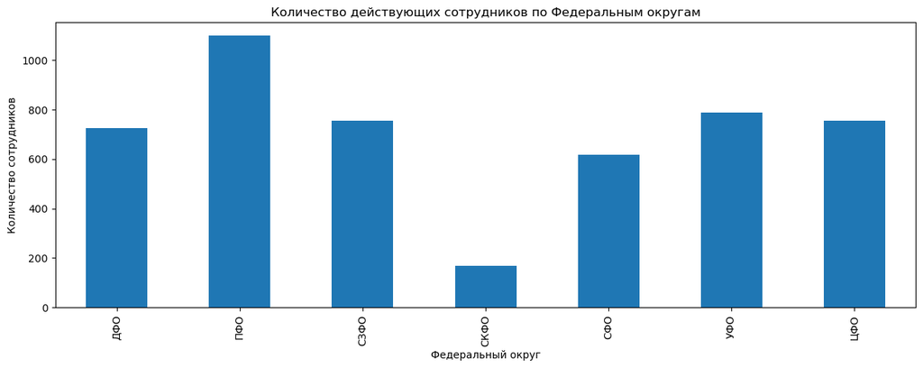

```python
(df
 .groupby('Федеральный округ')['ФИО']
 .count()
 .plot(kind='bar', figsize=(15,5))
 .set_title('Количество действующих сотрудников по Федеральным округам'))
plt.xlabel('Федеральный округ')
plt.ylabel('Количество сотрудников');
```

### Количество свободных должностей по регионам.

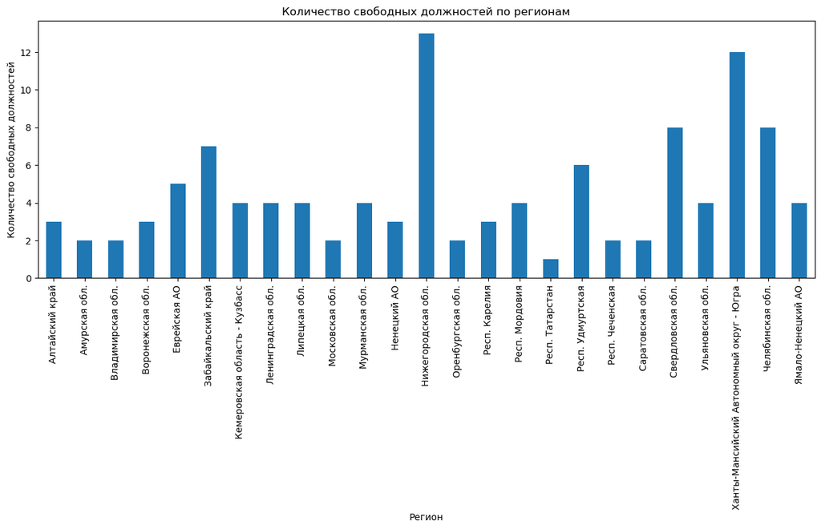

```python
(df[df['ФИО'].isna()]
 .groupby('Регион')['ID должности']
 .count()
 .plot(kind='bar', figsize=(15,5))
 .set_title('Количество свободных должностей по регионам'))
plt.xlabel('Регион')
plt.ylabel('Количество свободных должностей');
```